# Risk Factor Analysis

## Outcome Variable

**Outcome Variable:** wasted

## Predictor Variables

**Intervention Variable:** hhwealth_quart

**Adjustment Set:**

- arm
- sex
- W_mage
- meducyrs
- feducyrs
- W_gagebrth
- W_birthwt
- W_birthlen
- W_nchldlt5
- W_parity
- delta_W_mage
- delta_meducyrs
- delta_feducyrs
- delta_W_gagebrth
- delta_W_birthwt
- delta_W_birthlen
- delta_W_nchldlt5
- delta_W_parity

## Stratifying Variables

The analysis was stratified on these variable(s):

- agecat
- studyid
- country

## Data Summary

| agecat | studyid | country | hhwealth_quart | wasted | n_cell | n |
| --- | --- | --- | --- | --- | --- | --- |
| Birth | CMC-V-BCS-2002 | INDIA | Wealth Q4 | 0 | 26 | 86 |
| Birth | CMC-V-BCS-2002 | INDIA | Wealth Q4 | 1 | 6 | 86 |
| Birth | CMC-V-BCS-2002 | INDIA | Wealth Q1 | 0 | 12 | 86 |
| Birth | CMC-V-BCS-2002 | INDIA | Wealth Q1 | 1 | 1 | 86 |
| Birth | CMC-V-BCS-2002 | INDIA | Wealth Q2 | 0 | 16 | 86 |
| Birth | CMC-V-BCS-2002 | INDIA | Wealth Q2 | 1 | 3 | 86 |
| Birth | CMC-V-BCS-2002 | INDIA | Wealth Q3 | 0 | 21 | 86 |
| Birth | CMC-V-BCS-2002 | INDIA | Wealth Q3 | 1 | 1 | 86 |
| Birth | COHORTS | GUATEMALA | Wealth Q4 | 0 | 190 | 729 |
| Birth | COHORTS | GUATEMALA | Wealth Q4 | 1 | 68 | 729 |
| Birth | COHORTS | GUATEMALA | Wealth Q1 | 0 | 98 | 729 |
| Birth | COHORTS | GUATEMALA | Wealth Q1 | 1 | 46 | 729 |
| Birth | COHORTS | GUATEMALA | Wealth Q2 | 0 | 108 | 729 |
| Birth | COHORTS | GUATEMALA | Wealth Q2 | 1 | 33 | 729 |
| Birth | COHORTS | GUATEMALA | Wealth Q3 | 0 | 148 | 729 |
| Birth | COHORTS | GUATEMALA | Wealth Q3 | 1 | 38 | 729 |
| Birth | COHORTS | PHILIPPINES | Wealth Q4 | 0 | 671 | 2898 |
| Birth | COHORTS | PHILIPPINES | Wealth Q4 | 1 | 144 | 2898 |
| Birth | COHORTS | PHILIPPINES | Wealth Q1 | 0 | 533 | 2898 |
| Birth | COHORTS | PHILIPPINES | Wealth Q1 | 1 | 114 | 2898 |
| Birth | COHORTS | PHILIPPINES | Wealth Q2 | 0 | 442 | 2898 |
| Birth | COHORTS | PHILIPPINES | Wealth Q2 | 1 | 64 | 2898 |
| Birth | COHORTS | PHILIPPINES | Wealth Q3 | 0 | 801 | 2898 |
| Birth | COHORTS | PHILIPPINES | Wealth Q3 | 1 | 129 | 2898 |
| Birth | CONTENT | PERU | Wealth Q4 | 0 | 0 | 2 |
| Birth | CONTENT | PERU | Wealth Q4 | 1 | 0 | 2 |
| Birth | CONTENT | PERU | Wealth Q1 | 0 | 0 | 2 |
| Birth | CONTENT | PERU | Wealth Q1 | 1 | 0 | 2 |
| Birth | CONTENT | PERU | Wealth Q2 | 0 | 1 | 2 |
| Birth | CONTENT | PERU | Wealth Q2 | 1 | 0 | 2 |

[output cut: 386 more lines]

The following strata were considered:

- agecat: 24 months, studyid: CMC-V-BCS-2002, country: INDIA
- agecat: 24 months, studyid: COHORTS, country: GUATEMALA
- agecat: 24 months, studyid: COHORTS, country: PHILIPPINES
- agecat: 24 months, studyid: CONTENT, country: PERU
- agecat: 24 months, studyid: GMS-Nepal, country: NEPAL
- agecat: 24 months, studyid: IRC, country: INDIA
- agecat: 24 months, studyid: JiVitA-3, country: BANGLADESH
- agecat: 24 months, studyid: JiVitA-4, country: BANGLADESH
- agecat: 24 months, studyid: LCNI-5, country: MALAWI
- agecat: 24 months, studyid: MAL-ED, country: BANGLADESH
- agecat: 24 months, studyid: MAL-ED, country: BRAZIL
- agecat: 24 months, studyid: MAL-ED, country: INDIA
- agecat: 24 months, studyid: MAL-ED, country: NEPAL
- agecat: 24 months, studyid: MAL-ED, country: PERU
- agecat: 24 months, studyid: MAL-ED, country: SOUTH AFRICA
- agecat: 24 months, studyid: MAL-ED, country: TANZANIA, UNITED REPUBLIC OF
- agecat: 24 months, studyid: PROVIDE, country: BANGLADESH
- agecat: 24 months, studyid: TanzaniaChild2, country: TANZANIA, UNITED REPUBLIC OF
- agecat: 6 months, studyid: CMC-V-BCS-2002, country: INDIA
- agecat: 6 months, studyid: COHORTS, country: GUATEMALA
- agecat: 6 months, studyid: COHORTS, country: PHILIPPINES
- agecat: 6 months, studyid: CONTENT, country: PERU
- agecat: 6 months, studyid: GMS-Nepal, country: NEPAL
- agecat: 6 months, studyid: IRC, country: INDIA
- agecat: 6 months, studyid: JiVitA-3, country: BANGLADESH
- agecat: 6 months, studyid: JiVitA-4, country: BANGLADESH
- agecat: 6 months, studyid: LCNI-5, country: MALAWI
- agecat: 6 months, studyid: MAL-ED, country: BANGLADESH
- agecat: 6 months, studyid: MAL-ED, country: BRAZIL
- agecat: 6 months, studyid: MAL-ED, country: INDIA
- agecat: 6 months, studyid: MAL-ED, country: NEPAL
- agecat: 6 months, studyid: MAL-ED, country: PERU
- agecat: 6 months, studyid: MAL-ED, country: SOUTH AFRICA
- agecat: 6 months, studyid: MAL-ED, country: TANZANIA, UNITED REPUBLIC OF
- agecat: 6 months, studyid: PROVIDE, country: BANGLADESH
- agecat: 6 months, studyid: TanzaniaChild2, country: TANZANIA, UNITED REPUBLIC OF
- agecat: Birth, studyid: CMC-V-BCS-2002, country: INDIA
- agecat: Birth, studyid: COHORTS, country: GUATEMALA
- agecat: Birth, studyid: COHORTS, country: PHILIPPINES
- agecat: Birth, studyid: CONTENT, country: PERU
- agecat: Birth, studyid: GMS-Nepal, country: NEPAL
- agecat: Birth, studyid: IRC, country: INDIA
- agecat: Birth, studyid: JiVitA-3, country: BANGLADESH
- agecat: Birth, studyid: JiVitA-4, country: BANGLADESH
- agecat: Birth, studyid: MAL-ED, country: BANGLADESH
- agecat: Birth, studyid: MAL-ED, country: BRAZIL
- agecat: Birth, studyid: MAL-ED, country: INDIA
- agecat: Birth, studyid: MAL-ED, country: NEPAL
- agecat: Birth, studyid: MAL-ED, country: PERU
- agecat: Birth, studyid: MAL-ED, country: SOUTH AFRICA
- agecat: Birth, studyid: MAL-ED, country: TANZANIA, UNITED REPUBLIC OF
- agecat: Birth, studyid: PROVIDE, country: BANGLADESH

### Dropped Strata

Some strata were dropped due to rare outcomes:

- agecat: Birth, studyid: CMC-V-BCS-2002, country: INDIA
- agecat: Birth, studyid: CONTENT, country: PERU
- agecat: Birth, studyid: MAL-ED, country: BRAZIL
- agecat: Birth, studyid: MAL-ED, country: INDIA
- agecat: Birth, studyid: MAL-ED, country: NEPAL
- agecat: Birth, studyid: MAL-ED, country: PERU
- agecat: Birth, studyid: MAL-ED, country: SOUTH AFRICA
- agecat: Birth, studyid: MAL-ED, country: TANZANIA, UNITED REPUBLIC OF
- agecat: 6 months, studyid: CONTENT, country: PERU
- agecat: 6 months, studyid: LCNI-5, country: MALAWI
- agecat: 6 months, studyid: MAL-ED, country: BANGLADESH
- agecat: 6 months, studyid: MAL-ED, country: BRAZIL
- agecat: 6 months, studyid: MAL-ED, country: INDIA
- agecat: 6 months, studyid: MAL-ED, country: NEPAL
- agecat: 6 months, studyid: MAL-ED, country: PERU
- agecat: 6 months, studyid: MAL-ED, country: SOUTH AFRICA
- agecat: 6 months, studyid: MAL-ED, country: TANZANIA, UNITED REPUBLIC OF
- agecat: 24 months, studyid: CMC-V-BCS-2002, country: INDIA
- agecat: 24 months, studyid: CONTENT, country: PERU
- agecat: 24 months, studyid: LCNI-5, country: MALAWI
- agecat: 24 months, studyid: MAL-ED, country: BANGLADESH
- agecat: 24 months, studyid: MAL-ED, country: BRAZIL
- agecat: 24 months, studyid: MAL-ED, country: NEPAL
- agecat: 24 months, studyid: MAL-ED, country: PERU
- agecat: 24 months, studyid: MAL-ED, country: SOUTH AFRICA
- agecat: 24 months, studyid: MAL-ED, country: TANZANIA, UNITED REPUBLIC OF
- agecat: 24 months, studyid: TanzaniaChild2, country: TANZANIA, UNITED REPUBLIC OF

## Methods Detail

We’re interested in the causal parameters $E[Y_a]$ for all values of $a \in \mathcal{A}$. These parameters represent the mean outcome if, possibly contrary to fact, we intervened to set all units to have $A=a$. Under the randomization and positivity assumptions, these are identified by the statistical parameters $\psi_a=E_W[E_{Y|A,W}(Y|A=a,W)]$. In addition, we’re interested in the mean of $Y$, $E[Y]$ under no intervention (the observed mean). We will estimate these parameters by using SuperLearner to fit the relevant likelihood factors – $E_{Y|A,W}(Y|A=a,W)$ and $p(A=a|W)$, and then updating our likelihood fit using a joint TMLE.

For unadjusted analyses ($W=\{\}$), initial likelihoods were estimated using Lrnr_glm to estimate the simple $E(Y|A)$ and Lrnr_mean to estimate $p(A)$. For adjusted analyses, a small library containing Lrnr_glmnet, Lrnr_xgboost, and Lrnr_mean was used.

Having estimated these parameters, we will then use the delta method to estimate relative risks and attributable risks relative to a prespecified baseline level of $A$.

# Results Detail

## Results Plots

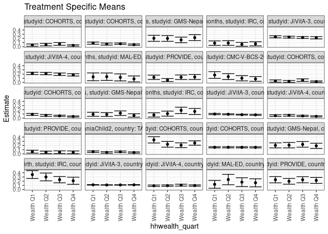

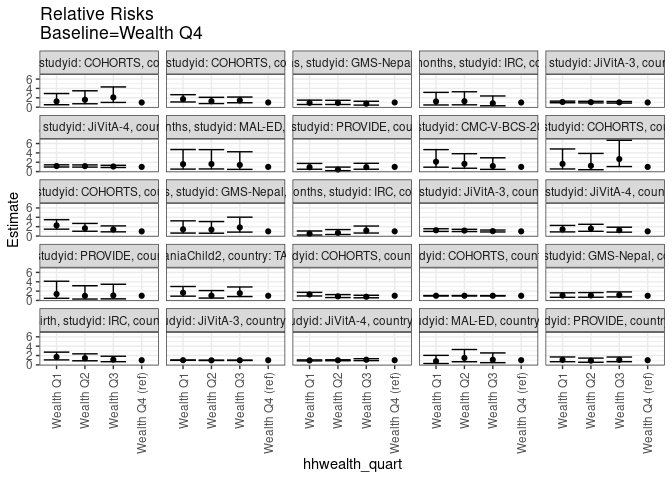

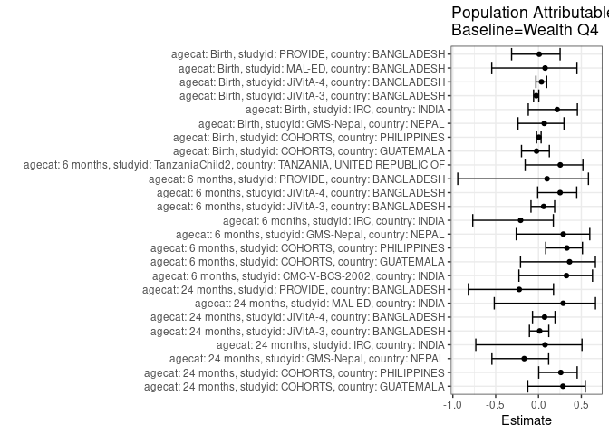

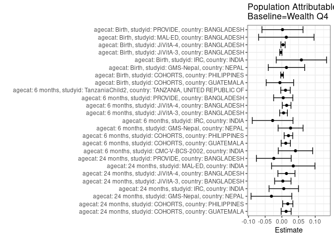

## Results Table

### Parameter: TSM

| agecat | studyid | country | intervention_level | baseline_level | estimate | ci_lower | ci_upper |
| --- | --- | --- | --- | --- | --- | --- | --- |
| Birth | COHORTS | GUATEMALA | Wealth Q4 | NA | 0.2595676 | 0.2075037 | 0.3116315 |
| Birth | COHORTS | GUATEMALA | Wealth Q1 | NA | 0.3337702 | 0.2585065 | 0.4090340 |
| Birth | COHORTS | GUATEMALA | Wealth Q2 | NA | 0.2281906 | 0.1601376 | 0.2962435 |
| Birth | COHORTS | GUATEMALA | Wealth Q3 | NA | 0.2055175 | 0.1484630 | 0.2625720 |
| Birth | COHORTS | PHILIPPINES | Wealth Q4 | NA | 0.1549067 | 0.1410558 | 0.1687576 |
| Birth | COHORTS | PHILIPPINES | Wealth Q1 | NA | 0.1560396 | 0.1421104 | 0.1699687 |
| Birth | COHORTS | PHILIPPINES | Wealth Q2 | NA | 0.1561071 | 0.1416935 | 0.1705207 |
| Birth | COHORTS | PHILIPPINES | Wealth Q3 | NA | 0.1555764 | 0.1419486 | 0.1692041 |
| Birth | GMS-Nepal | NEPAL | Wealth Q4 | NA | 0.1921228 | 0.1296474 | 0.2545982 |
| Birth | GMS-Nepal | NEPAL | Wealth Q1 | NA | 0.2016944 | 0.1416827 | 0.2617061 |
| Birth | GMS-Nepal | NEPAL | Wealth Q2 | NA | 0.2061842 | 0.1419262 | 0.2704423 |
| Birth | GMS-Nepal | NEPAL | Wealth Q3 | NA | 0.2263763 | 0.1594587 | 0.2932938 |
| Birth | IRC | INDIA | Wealth Q4 | NA | 0.2096733 | 0.1244733 | 0.2948733 |
| Birth | IRC | INDIA | Wealth Q1 | NA | 0.3566919 | 0.2635008 | 0.4498831 |
| Birth | IRC | INDIA | Wealth Q2 | NA | 0.3008302 | 0.2076746 | 0.3939858 |
| Birth | IRC | INDIA | Wealth Q3 | NA | 0.2356242 | 0.1609941 | 0.3102544 |
| Birth | JiVitA-3 | BANGLADESH | Wealth Q4 | NA | 0.1125347 | 0.1064657 | 0.1186037 |
| Birth | JiVitA-3 | BANGLADESH | Wealth Q1 | NA | 0.1126394 | 0.1067855 | 0.1184934 |
| Birth | JiVitA-3 | BANGLADESH | Wealth Q2 | NA | 0.1094804 | 0.1039562 | 0.1150045 |
| Birth | JiVitA-3 | BANGLADESH | Wealth Q3 | NA | 0.1100869 | 0.1044936 | 0.1156802 |
| Birth | JiVitA-4 | BANGLADESH | Wealth Q4 | NA | 0.0959308 | 0.0803215 | 0.1115401 |
| Birth | JiVitA-4 | BANGLADESH | Wealth Q1 | NA | 0.0914178 | 0.0744163 | 0.1084192 |
| Birth | JiVitA-4 | BANGLADESH | Wealth Q2 | NA | 0.0942241 | 0.0772553 | 0.1111929 |
| Birth | JiVitA-4 | BANGLADESH | Wealth Q3 | NA | 0.1055101 | 0.0829321 | 0.1280882 |
| Birth | MAL-ED | BANGLADESH | Wealth Q4 | NA | 0.1607143 | 0.0642827 | 0.2571459 |
| Birth | MAL-ED | BANGLADESH | Wealth Q1 | NA | 0.1250000 | 0.0312072 | 0.2187928 |
| Birth | MAL-ED | BANGLADESH | Wealth Q2 | NA | 0.2391304 | 0.1155571 | 0.3627038 |
| Birth | MAL-ED | BANGLADESH | Wealth Q3 | NA | 0.1764706 | 0.0715836 | 0.2813576 |
| Birth | PROVIDE | BANGLADESH | Wealth Q4 | NA | 0.2180237 | 0.1473056 | 0.2887418 |
| Birth | PROVIDE | BANGLADESH | Wealth Q1 | NA | 0.2344944 | 0.1596350 | 0.3093538 |

[output cut: 70 more lines]

### Parameter: E(Y)

| agecat | studyid | country | intervention_level | baseline_level | estimate | ci_lower | ci_upper |
| --- | --- | --- | --- | --- | --- | --- | --- |
| Birth | COHORTS | GUATEMALA | NA | NA | 0.2537723 | 0.2221611 | 0.2853834 |
| Birth | COHORTS | PHILIPPINES | NA | NA | 0.1556246 | 0.1424244 | 0.1688248 |
| Birth | GMS-Nepal | NEPAL | NA | NA | 0.2059282 | 0.1745993 | 0.2372572 |
| Birth | IRC | INDIA | NA | NA | 0.2682216 | 0.2212677 | 0.3151755 |
| Birth | JiVitA-3 | BANGLADESH | NA | NA | 0.1096477 | 0.1045230 | 0.1147723 |
| Birth | JiVitA-4 | BANGLADESH | NA | NA | 0.0994152 | 0.0840401 | 0.1147903 |
| Birth | MAL-ED | BANGLADESH | NA | NA | 0.1741294 | 0.1215730 | 0.2266857 |
| Birth | PROVIDE | BANGLADESH | NA | NA | 0.2199248 | 0.1846953 | 0.2551543 |
| 6 months | CMC-V-BCS-2002 | INDIA | NA | NA | 0.1250000 | 0.0911644 | 0.1588356 |
| 6 months | COHORTS | GUATEMALA | NA | NA | 0.0323974 | 0.0209875 | 0.0438073 |
| 6 months | COHORTS | PHILIPPINES | NA | NA | 0.0594974 | 0.0505830 | 0.0684118 |
| 6 months | GMS-Nepal | NEPAL | NA | NA | 0.0904255 | 0.0667359 | 0.1141152 |
| 6 months | IRC | INDIA | NA | NA | 0.1323529 | 0.0994307 | 0.1652752 |
| 6 months | JiVitA-3 | BANGLADESH | NA | NA | 0.0845851 | 0.0797798 | 0.0893904 |
| 6 months | JiVitA-4 | BANGLADESH | NA | NA | 0.0569712 | 0.0481278 | 0.0658146 |
| 6 months | PROVIDE | BANGLADESH | NA | NA | 0.0414594 | 0.0255348 | 0.0573839 |
| 6 months | TanzaniaChild2 | TANZANIA, UNITED REPUBLIC OF | NA | NA | 0.0430906 | 0.0342310 | 0.0519502 |
| 24 months | COHORTS | GUATEMALA | NA | NA | 0.0449331 | 0.0323731 | 0.0574931 |
| 24 months | COHORTS | PHILIPPINES | NA | NA | 0.0681911 | 0.0582056 | 0.0781766 |
| 24 months | GMS-Nepal | NEPAL | NA | NA | 0.1868583 | 0.1522030 | 0.2215136 |
| 24 months | IRC | INDIA | NA | NA | 0.0757946 | 0.0501131 | 0.1014762 |
| 24 months | JiVitA-3 | BANGLADESH | NA | NA | 0.2180591 | 0.2081778 | 0.2279404 |
| 24 months | JiVitA-4 | BANGLADESH | NA | NA | 0.1945032 | 0.1812962 | 0.2077102 |
| 24 months | MAL-ED | INDIA | NA | NA | 0.1189427 | 0.0767376 | 0.1611478 |
| 24 months | PROVIDE | BANGLADESH | NA | NA | 0.1070812 | 0.0818727 | 0.1322897 |

### Parameter: RR

| agecat | studyid | country | intervention_level | baseline_level | estimate | ci_lower | ci_upper |
| --- | --- | --- | --- | --- | --- | --- | --- |
| Birth | COHORTS | GUATEMALA | Wealth Q4 | Wealth Q4 | 1.0000000 | 1.0000000 | 1.0000000 |
| Birth | COHORTS | GUATEMALA | Wealth Q1 | Wealth Q4 | 1.2858702 | 0.9541111 | 1.7329871 |
| Birth | COHORTS | GUATEMALA | Wealth Q2 | Wealth Q4 | 0.8791181 | 0.6168697 | 1.2528556 |
| Birth | COHORTS | GUATEMALA | Wealth Q3 | Wealth Q4 | 0.7917688 | 0.5645784 | 1.1103824 |
| Birth | COHORTS | PHILIPPINES | Wealth Q4 | Wealth Q4 | 1.0000000 | 1.0000000 | 1.0000000 |
| Birth | COHORTS | PHILIPPINES | Wealth Q1 | Wealth Q4 | 1.0073131 | 0.9637827 | 1.0528096 |
| Birth | COHORTS | PHILIPPINES | Wealth Q2 | Wealth Q4 | 1.0077493 | 0.9569669 | 1.0612265 |
| Birth | COHORTS | PHILIPPINES | Wealth Q3 | Wealth Q4 | 1.0043229 | 0.9623683 | 1.0481067 |
| Birth | GMS-Nepal | NEPAL | Wealth Q4 | Wealth Q4 | 1.0000000 | 1.0000000 | 1.0000000 |
| Birth | GMS-Nepal | NEPAL | Wealth Q1 | Wealth Q4 | 1.0498204 | 0.6756435 | 1.6312195 |
| Birth | GMS-Nepal | NEPAL | Wealth Q2 | Wealth Q4 | 1.0731900 | 0.6840343 | 1.6837414 |
| Birth | GMS-Nepal | NEPAL | Wealth Q3 | Wealth Q4 | 1.1782895 | 0.7589619 | 1.8292964 |
| Birth | IRC | INDIA | Wealth Q4 | Wealth Q4 | 1.0000000 | 1.0000000 | 1.0000000 |
| Birth | IRC | INDIA | Wealth Q1 | Wealth Q4 | 1.7011798 | 1.0615776 | 2.7261432 |
| Birth | IRC | INDIA | Wealth Q2 | Wealth Q4 | 1.4347571 | 0.8709086 | 2.3636557 |
| Birth | IRC | INDIA | Wealth Q3 | Wealth Q4 | 1.1237684 | 0.6811183 | 1.8540912 |
| Birth | JiVitA-3 | BANGLADESH | Wealth Q4 | Wealth Q4 | 1.0000000 | 1.0000000 | 1.0000000 |
| Birth | JiVitA-3 | BANGLADESH | Wealth Q1 | Wealth Q4 | 1.0009303 | 0.9612815 | 1.0422144 |
| Birth | JiVitA-3 | BANGLADESH | Wealth Q2 | Wealth Q4 | 0.9728582 | 0.9368071 | 1.0102967 |
| Birth | JiVitA-3 | BANGLADESH | Wealth Q3 | Wealth Q4 | 0.9782484 | 0.9406811 | 1.0173159 |
| Birth | JiVitA-4 | BANGLADESH | Wealth Q4 | Wealth Q4 | 1.0000000 | 1.0000000 | 1.0000000 |
| Birth | JiVitA-4 | BANGLADESH | Wealth Q1 | Wealth Q4 | 0.9529557 | 0.8526083 | 1.0651135 |
| Birth | JiVitA-4 | BANGLADESH | Wealth Q2 | Wealth Q4 | 0.9822093 | 0.8848898 | 1.0902321 |
| Birth | JiVitA-4 | BANGLADESH | Wealth Q3 | Wealth Q4 | 1.0998571 | 0.9122912 | 1.3259862 |
| Birth | MAL-ED | BANGLADESH | Wealth Q4 | Wealth Q4 | 1.0000000 | 1.0000000 | 1.0000000 |
| Birth | MAL-ED | BANGLADESH | Wealth Q1 | Wealth Q4 | 0.7777778 | 0.2975830 | 2.0328390 |
| Birth | MAL-ED | BANGLADESH | Wealth Q2 | Wealth Q4 | 1.4879227 | 0.6740216 | 3.2846335 |
| Birth | MAL-ED | BANGLADESH | Wealth Q3 | Wealth Q4 | 1.0980392 | 0.4718772 | 2.5550931 |
| Birth | PROVIDE | BANGLADESH | Wealth Q4 | Wealth Q4 | 1.0000000 | 1.0000000 | 1.0000000 |
| Birth | PROVIDE | BANGLADESH | Wealth Q1 | Wealth Q4 | 1.0755455 | 0.6821006 | 1.6959348 |

[output cut: 70 more lines]

### Parameter: PAR

| agecat | studyid | country | intervention_level | baseline_level | estimate | ci_lower | ci_upper |
| --- | --- | --- | --- | --- | --- | --- | --- |
| Birth | COHORTS | GUATEMALA | Wealth Q4 | NA | -0.0057953 | -0.0468730 | 0.0352825 |
| Birth | COHORTS | PHILIPPINES | Wealth Q4 | NA | 0.0007179 | -0.0033964 | 0.0048322 |
| Birth | GMS-Nepal | NEPAL | Wealth Q4 | NA | 0.0138055 | -0.0407462 | 0.0683571 |
| Birth | IRC | INDIA | Wealth Q4 | NA | 0.0585483 | -0.0169537 | 0.1340502 |
| Birth | JiVitA-3 | BANGLADESH | Wealth Q4 | NA | -0.0028871 | -0.0062180 | 0.0004439 |
| Birth | JiVitA-4 | BANGLADESH | Wealth Q4 | NA | 0.0034844 | -0.0028212 | 0.0097900 |
| Birth | MAL-ED | BANGLADESH | Wealth Q4 | NA | 0.0134151 | -0.0695286 | 0.0963588 |
| Birth | PROVIDE | BANGLADESH | Wealth Q4 | NA | 0.0019011 | -0.0595591 | 0.0633614 |
| 6 months | CMC-V-BCS-2002 | INDIA | Wealth Q4 | NA | 0.0407895 | -0.0107598 | 0.0923387 |
| 6 months | COHORTS | GUATEMALA | Wealth Q4 | NA | 0.0117484 | -0.0020944 | 0.0255913 |
| 6 months | COHORTS | PHILIPPINES | Wealth Q4 | NA | 0.0197664 | 0.0068704 | 0.0326625 |
| 6 months | GMS-Nepal | NEPAL | Wealth Q4 | NA | 0.0261398 | -0.0111938 | 0.0634734 |
| 6 months | IRC | INDIA | Wealth Q4 | NA | -0.0276471 | -0.0886587 | 0.0333646 |
| 6 months | JiVitA-3 | BANGLADESH | Wealth Q4 | NA | 0.0051037 | -0.0065215 | 0.0167289 |
| 6 months | JiVitA-4 | BANGLADESH | Wealth Q4 | NA | 0.0143867 | 0.0013979 | 0.0273754 |
| 6 months | PROVIDE | BANGLADESH | Wealth Q4 | NA | 0.0041459 | -0.0246054 | 0.0328972 |
| 6 months | TanzaniaChild2 | TANZANIA, UNITED REPUBLIC OF | Wealth Q4 | NA | 0.0109463 | -0.0032909 | 0.0251834 |
| 24 months | COHORTS | GUATEMALA | Wealth Q4 | NA | 0.0128343 | -0.0021425 | 0.0278111 |
| 24 months | COHORTS | PHILIPPINES | Wealth Q4 | NA | 0.0177581 | 0.0024285 | 0.0330877 |
| 24 months | GMS-Nepal | NEPAL | Wealth Q4 | NA | -0.0311635 | -0.0922272 | 0.0299002 |
| 24 months | IRC | INDIA | Wealth Q4 | NA | 0.0057946 | -0.0382574 | 0.0498467 |
| 24 months | JiVitA-3 | BANGLADESH | Wealth Q4 | NA | 0.0029591 | -0.0216067 | 0.0275248 |
| 24 months | JiVitA-4 | BANGLADESH | Wealth Q4 | NA | 0.0137763 | -0.0117948 | 0.0393475 |
| 24 months | MAL-ED | INDIA | Wealth Q4 | NA | 0.0341970 | -0.0307412 | 0.0991351 |
| 24 months | PROVIDE | BANGLADESH | Wealth Q4 | NA | -0.0240664 | -0.0761717 | 0.0280390 |

### Parameter: PAF

| agecat | studyid | country | intervention_level | baseline_level | estimate | ci_lower | ci_upper |
| --- | --- | --- | --- | --- | --- | --- | --- |
| Birth | COHORTS | GUATEMALA | Wealth Q4 | NA | -0.0228366 | -0.1982151 | 0.1268724 |
| Birth | COHORTS | PHILIPPINES | Wealth Q4 | NA | 0.0046128 | -0.0221842 | 0.0307073 |
| Birth | GMS-Nepal | NEPAL | Wealth Q4 | NA | 0.0670401 | -0.2393481 | 0.2976839 |
| Birth | IRC | INDIA | Wealth Q4 | NA | 0.2182833 | -0.1192867 | 0.4540442 |
| Birth | JiVitA-3 | BANGLADESH | Wealth Q4 | NA | -0.0263306 | -0.0572085 | 0.0036455 |
| Birth | JiVitA-4 | BANGLADESH | Wealth Q4 | NA | 0.0350492 | -0.0297819 | 0.0957988 |
| Birth | MAL-ED | BANGLADESH | Wealth Q4 | NA | 0.0770408 | -0.5458102 | 0.4489274 |
| Birth | PROVIDE | BANGLADESH | Wealth Q4 | NA | 0.0086444 | -0.3141801 | 0.2521680 |
| 6 months | CMC-V-BCS-2002 | INDIA | Wealth Q4 | NA | 0.3263158 | -0.2283944 | 0.6305336 |
| 6 months | COHORTS | GUATEMALA | Wealth Q4 | NA | 0.3626352 | -0.2100558 | 0.6642850 |
| 6 months | COHORTS | PHILIPPINES | Wealth Q4 | NA | 0.3322231 | 0.0840470 | 0.5131563 |
| 6 months | GMS-Nepal | NEPAL | Wealth Q4 | NA | 0.2890756 | -0.2599919 | 0.5988756 |
| 6 months | IRC | INDIA | Wealth Q4 | NA | -0.2088889 | -0.7673694 | 0.1731144 |
| 6 months | JiVitA-3 | BANGLADESH | Wealth Q4 | NA | 0.0603381 | -0.0876400 | 0.1881831 |
| 6 months | JiVitA-4 | BANGLADESH | Wealth Q4 | NA | 0.2525251 | -0.0093219 | 0.4464415 |
| 6 months | PROVIDE | BANGLADESH | Wealth Q4 | NA | 0.1000000 | -0.9427092 | 0.5830565 |
| 6 months | TanzaniaChild2 | TANZANIA, UNITED REPUBLIC OF | Wealth Q4 | NA | 0.2540285 | -0.1557537 | 0.5185190 |
| 24 months | COHORTS | GUATEMALA | Wealth Q4 | NA | 0.2856317 | -0.1247612 | 0.5462841 |
| 24 months | COHORTS | PHILIPPINES | Wealth Q4 | NA | 0.2604165 | 0.0028473 | 0.4514544 |
| 24 months | GMS-Nepal | NEPAL | Wealth Q4 | NA | -0.1667761 | -0.5440180 | 0.1182962 |
| 24 months | IRC | INDIA | Wealth Q4 | NA | 0.0764516 | -0.7319580 | 0.5075275 |
| 24 months | JiVitA-3 | BANGLADESH | Wealth Q4 | NA | 0.0135700 | -0.1058054 | 0.1200584 |
| 24 months | JiVitA-4 | BANGLADESH | Wealth Q4 | NA | 0.0708284 | -0.0697529 | 0.1929352 |
| 24 months | MAL-ED | INDIA | Wealth Q4 | NA | 0.2875078 | -0.5164954 | 0.6652512 |
| 24 months | PROVIDE | BANGLADESH | Wealth Q4 | NA | -0.2247488 | -0.8191640 | 0.1754401 |